# TP-02 Javier Duque

## Carga de los datos

Comenzamos leyendo el dataframe y se muestra la estructura de las variables, el tipo de datos

```r
#Se cargan las librerias a usar
library(readr)
library(tidyverse)
library(tidymodels)
library(dplyr)
library(OneR)
```

```r
#Se lee el dataset y se procede a revisar la estructura de los datos
ar_properties <- read_rds("~/GitHub/EEA2019/TP-2/ar_properties.rds")
glimpse(ar_properties)
```

```
Observations: 45,904
Variables: 8
$ id              <chr> "AfdcsqUSelai1ofCAq2B0Q==", "ESzybdH7YU2uIU1/kHtRGw==", "r22OfzZ3kXooSPoE5HM...
$ l3              <chr> "Velez Sarsfield", "Nuñez", "Almagro", "Almagro", "Almagro", "Almagro", "Alm...
$ rooms           <dbl> 3, 1, 1, 1, 1, 1, 1, 1, 1, 1, 1, 1, 1, 1, 3, 1, 1, 2, 1, 1, 1, 1, 1, 1, 2, 1...
$ bathrooms       <dbl> 2, 1, 1, 1, 1, 1, 1, 1, 1, 1, 1, 1, 1, 1, 2, 1, 1, 1, 1, 1, 1, 1, 1, 1, 2, 1...
$ surface_total   <dbl> 95, 44, 40, 49, 40, 40, 40, 49, 40, 40, 40, 32, 40, 36, 90, 45, 54, 40, 33, ...
$ surface_covered <dbl> 69, 38, 37, 44, 37, 37, 37, 44, 37, 37, 37, 30, 34, 33, 90, 35, 48, 40, 32, ...
$ price           <dbl> 199900, 147000, 92294, 115000, 77000, 88900, 88798, 110975, 92943, 99000, 96...
$ property_type   <chr> "Casa", "Departamento", "Departamento", "Departamento", "Departamento", "Dep...
```

## 1. Regresión lineal múltiple

### a) Crear un modelo para predecir el precio con todas las covariables.

```r
#SE filtra la variable ID
ar_propertieslm <- ar_properties %>%
  select(.,-c(id))

#Se realiza una regresion multiple de precio con respecto a todas las covariables
lmcompleto <- lm(price~., data = ar_propertieslm)
#ver el resultado del modelo
summary(lmcompleto)
```

```
Call:
lm(formula = price ~ ., data = ar_propertieslm)

Residuals:
    Min      1Q  Median      3Q     Max
-400904  -33817   -3307   24660  560915

Coefficients:
                            Estimate Std. Error t value Pr(>|t|)
(Intercept)               -109406.61    4788.67 -22.847  < 2e-16 ***
l3Agronomía                   623.53    8846.14   0.070 0.943807
l3Almagro                   -4520.04    4295.24  -1.052 0.292650
l3Balvanera                -24788.27    4551.65  -5.446 5.18e-08 ***
l3Barracas                 -10128.24    5351.06  -1.893 0.058397 .
l3Barrio Norte              49921.81    4417.82  11.300  < 2e-16 ***
l3Belgrano                  69648.12    4283.55  16.259  < 2e-16 ***
l3Boca                     -47540.60    7076.20  -6.718 1.86e-11 ***
l3Boedo                    -19034.38    5219.54  -3.647 0.000266 ***
l3Caballito                  6220.15    4301.29   1.446 0.148153
l3Catalinas                -76321.95   33563.74  -2.274 0.022974 *
l3Centro / Microcentro     -29046.49    6781.80  -4.283 1.85e-05 ***
l3Chacarita                 11903.39    5299.02   2.246 0.024687 *
l3Coghlan                   40820.55    5462.90   7.472 8.02e-14 ***
l3Colegiales                34073.02    4816.54   7.074 1.52e-12 ***
l3Congreso                 -32314.97    5494.75  -5.881 4.10e-09 ***
l3Constitución             -47292.98    6321.63  -7.481 7.50e-14 ***
l3Flores                   -22510.27    4536.15  -4.962 6.99e-07 ***
l3Floresta                 -28315.65    5069.38  -5.586 2.34e-08 ***
l3Las Cañitas               90455.90    5883.38  15.375  < 2e-16 ***
l3Liniers                  -20080.34    5366.27  -3.742 0.000183 ***
l3Mataderos                -33863.43    5424.79  -6.242 4.35e-10 ***
l3Monserrat                -32431.49    5228.46  -6.203 5.59e-10 ***
l3Monte Castro              -8770.72    5949.63  -1.474 0.140445
l3Nuñez                     56958.42    4559.69  12.492  < 2e-16 ***
l3Once                     -30757.83    5456.51  -5.637 1.74e-08 ***
l3Palermo                   66169.58    4221.50  15.674  < 2e-16 ***
l3Parque Avellaneda        -34398.95    7598.09  -4.527 5.99e-06 ***
l3Parque Centenario        -12288.30    5016.45  -2.450 0.014305 *
l3Parque Chacabuco         -22537.83    5314.36  -4.241 2.23e-05 ***
l3Parque Chas                5195.26    7542.97   0.689 0.490981
```

[output cut: 23 more lines]

```
l3Villa Santa Rita          -5767.71    6383.86  -0.903 0.366274
l3Villa Soldati           -136489.91   18944.29  -7.205 5.90e-13 ***
l3Villa Urquiza             30648.43    4418.91   6.936 4.09e-12 ***
rooms                       -3961.27     444.58  -8.910  < 2e-16 ***
bathrooms                   34040.98     644.28  52.836  < 2e-16 ***
surface_total                 919.08      23.52  39.069  < 2e-16 ***
surface_covered              1457.18      28.73  50.715  < 2e-16 ***
property_typeDepartamento   92653.32    2191.23  42.284  < 2e-16 ***
property_typePH             46779.37    2274.94  20.563  < 2e-16 ***
---
Signif. codes:  0 ‘***’ 0.001 ‘**’ 0.01 ‘*’ 0.05 ‘.’ 0.1 ‘ ’ 1

Residual standard error: 66580 on 45841 degrees of freedom
Multiple R-squared:  0.7764,    Adjusted R-squared:  0.7761
F-statistic:  2568 on 62 and 45841 DF,  p-value: < 2.2e-16
```

### b) Analizar los resultados del modelo:

1. Interpretación de los coeficientes estimados

Se puede ver que debido a que se tienen dos variables de tipo categoricas (propoerty_type y l3), el sistema elige como categorias basales property_type = Casa y l3 = Abasto.

Vamos a analizar los coeficientes de las variables que no son dummys.

Se puede observar que el coeficiente estimado para la variable rooms es -3961.27, esto indica que si una propiedad aumenta en una habitacion su valor de precio esperado disminuye en 3961.27 dolares, teniendo el resto de las variables constantes; los coeficientes estimados de las otras variables bathrooms, surface_total, surface_covered, son positivos lo que indica que si aumentan su valor en una unidad de medida su valor de precio estimado aumenta; el coeficiente estimado para la variable bathrooms es de 34040.98 lo que quiere decir que si se aumenta un baño el valor del precio esperado de la propiedad aumenta en 34040.98 dolares, lo que muestra que es una variable que tiene un grado de importancia en cuanto al valor estimado del precio, si el resto de las variables se mantienen constantes.

En cuanto a las variables categoricas, que se convierten en variables dummy se interpretan de la siguiente forma: se interpreta en cuanto al cambio de una propiedad con los mismos valores en cuanto a las otras variables , tendria ese valor de cambio si cambia la categoria, si es positivo tendria un aumento en el valor estimado de precio, si es negativo tendria una disminucion en el valor estimado del precio.

2. ¿Qué observan respecto de la significatividad de las variables dummy?

```r
#Se evalua anova en el modelo
anova(lmcompleto)
```

```
Analysis of Variance Table

Response: price
                   Df     Sum Sq    Mean Sq  F value    Pr(>F)
l3                 56 1.8443e+14 3.2934e+12   742.95 < 2.2e-16 ***
rooms               1 3.0174e+14 3.0174e+14 68067.54 < 2.2e-16 ***
bathrooms           1 9.7588e+13 9.7588e+13 22014.36 < 2.2e-16 ***
surface_total       1 9.6762e+13 9.6762e+13 21827.91 < 2.2e-16 ***
surface_covered     1 1.2667e+13 1.2667e+13  2857.40 < 2.2e-16 ***
property_type       2 1.2491e+13 6.2453e+12  1408.85 < 2.2e-16 ***
Residuals       45841 2.0321e+14 4.4329e+09
---
Signif. codes:  0 ‘***’ 0.001 ‘**’ 0.01 ‘*’ 0.05 ‘.’ 0.1 ‘ ’ 1
```

3. Medidas de evaluación del modelo

```r
#Se piden las medidas de evaluacion del modelo
glance(lmcompleto)
```

| r.squared | adj.r.squared | sigma | statistic | p.value | df | logLik | AIC | BIC | deviance | df.residual |
| --- | --- | --- | --- | --- | --- | --- | --- | --- | --- | --- |
| 0.7764191 | 0.7761168 | 66580.31 | 2567.58 | 0 | 63 | -574920.8 | 1149970 | 1150529 | 2.032103e+14 | 45841 |

Se observa que el valor de R cuadrado ajustado da 0.776 lo que nos muestra que el modelo de regresion que se realizo con el conjunto de covariables logra explicar en un 77% el valor de la variable precio estimado.

### c) ¿Qué es preferible tener para vender?:

1. Un departamento de 120 mts cuadrados cubiertos en abasto, con 3 dormitorios y 2 baños
2. Un PH en balvanera, con 80 mts cuadrados cubiertos, 20 mts cuadrados no cubiertos, 2 dormitorios y 3 baños.

```r
# Se crean las dos observaciones nuevas
deptoabasto =  data.frame( property_type = "Departamento",
                           surface_covered = 120,
                           surface_total = 120,
                           l3 = "Abasto",
                           rooms = 3,
                           bathrooms = 2 )

phbalva =  data.frame(  property_type = "PH",
                        l3 = "Balvanera",
                        surface_covered = 80,
                        surface_total = 100,
                        rooms = 2,
                        bathrooms = 3 )

#Se realiza la prediccion y se muestran los resultados
predicciones <- as.data.frame(predict(lmcompleto, deptoabasto, interval = "predict"))
predicciones %>%
  bind_rows(as.data.frame(predict(lmcompleto, phbalva, interval = "predict")))
```

| fit | lwr | upr |
| --- | --- | --- |
| 324596.4 | 193837.52 | 455355.3 |
| 215267.6 | 84678.03 | 345857.2 |

Se evidencia que es preferible tener para vender “Un departamento de 120 mts cuadrados cubiertos en abasto, con 3 dormitorios y 2 baños” porque nos da un mayor valor en el precio el cuales de 324596.4 dolares

### d) Realizar un modelo sin la covariable l3 e interpretar sus resultados

```r
#Se realiza una regresion multiple de precio con respecto a todas las covariables excepto l3
ar_propertiessinl3 <- ar_properties %>%
  select(.,-c(l3,id))


lmsinl3 <- lm(price ~ ., data = ar_propertiessinl3)
#ver el resultado del modelo
summary(lmsinl3)
```

```
Call:
lm(formula = price ~ ., data = ar_propertiessinl3)

Residuals:
    Min      1Q  Median      3Q     Max
-518799  -36177   -9643   25740  724251

Coefficients:
                            Estimate Std. Error t value Pr(>|t|)
(Intercept)               -131096.86    2750.50  -47.66   <2e-16 ***
rooms                      -13348.53     519.02  -25.72   <2e-16 ***
bathrooms                   42664.68     756.37   56.41   <2e-16 ***
surface_total                 877.03      27.59   31.79   <2e-16 ***
surface_covered              1783.80      33.53   53.21   <2e-16 ***
property_typeDepartamento  135177.47    2513.93   53.77   <2e-16 ***
property_typePH             68598.52    2677.46   25.62   <2e-16 ***
---
Signif. codes:  0 ‘***’ 0.001 ‘**’ 0.01 ‘*’ 0.05 ‘.’ 0.1 ‘ ’ 1

Residual standard error: 79210 on 45897 degrees of freedom
Multiple R-squared:  0.6832,    Adjusted R-squared:  0.6831
F-statistic: 1.649e+04 on 6 and 45897 DF,  p-value: < 2.2e-16
```

Se puede observar que el coeficiente estimado para la variable rooms es -13348.53, esto indica que si una propiedad aumenta en una habitacion su valor de precio esperado disminuye en 13348.53 dolares, teniendo el resto de las variables constantes; los coeficientes estimados de las otras variables bathrooms, surface_total, surface_covered, son positivos lo que indica que si aumentan su valor en una unidad de medida su valor de precio esperado aumenta; En cuanto al coeficiente de la superficie cubierta si se aumenta en un m2 el precio estimado para una propiedad con el resto de las variables constantes aumentaria en 1783 dolares.

### e) ¿Cuál es el modelo que mejor explica la variabilidad del precio?

```r
#Mostrar los resultados de los modelos completo y con barrio por estrato
resutadoslm <- as.data.frame(glance(lmcompleto))
resutadoslm %>%
  bind_rows(as.data.frame(glance(lmsinl3)))
```

| r.squared | adj.r.squared | sigma | statistic | p.value | df | logLik | AIC | BIC | deviance | df.residual |
| --- | --- | --- | --- | --- | --- | --- | --- | --- | --- | --- |
| 0.7764191 | 0.7761168 | 66580.31 | 2567.58 | 0 | 63 | -574920.8 | 1149970 | 1150529 | 2.032103e+14 | 45841 |
| 0.6831564 | 0.6831149 | 79211.07 | 16493.32 | 0 | 7 | -582922.7 | 1165861 | 1165931 | 2.879758e+14 | 45897 |

Se puede ver de acuerdo al valor del R cuadrado ajustado que el modelo que logra explicar mejor es el que tiene los barrios (l3), puede ser porque tiene mas variables lo que hace que logre explicar mejor. El R cuadrado ajustado para el modelo completo es 0.77 (77%) y para el modelo sin l3 es 0.68 (68%)

## 2. Creación de variables:

### a) Crear variable precio por metro cuadrado

En el ejercicio anterior encontramos que algunos barrios son significativos, aunque no todos. Crear una nueva variable barrios que divida a los barrios según el precio por metro cuadrado promedio de las propiedades en ellos, con los grupos c(‘alto’, ‘medio’, ‘bajo’). Realizar un análisis exploratorio para definir los puntos de corte de la nueva variable y explicar los criterios utilizados en la construcción de la misma.

```r
# Crear una variable de precio por metro cuadrado
precio_medio_barrio <- ar_properties %>%
  group_by(l3) %>%
  summarise(mediaprecio= mean(price/surface_total)) %>%
  arrange(desc(mediaprecio))

precio_medio_barrio
```

| l3 | mediaprecio |
| --- | --- |
| Puerto Madero | 5471.555 |
| Las Cañitas | 3534.095 |
| Palermo | 3350.474 |
| Belgrano | 3316.104 |
| Recoleta | 3273.964 |
| Nuñez | 3212.144 |
| Barrio Norte | 3205.518 |
| Retiro | 2950.488 |
| Colegiales | 2861.160 |
| Coghlan | 2846.760 |

[output cut: 47 more lines]

```r
#Se crean tres niveles de acuerdo a la variable de precio por metro cuadrado
precio_medio_barrio <- precio_medio_barrio %>%
  filter(mediaprecio != min(mediaprecio),mediaprecio != max(mediaprecio)) %>%
  mutate(barrios = bin(mediaprecio, nbins = 3, labels = c("bajo", "medio", "alto")))

precio_medio_barrio
```

| l3 | mediaprecio | barrios |
| --- | --- | --- |
| Las Cañitas | 3534.095 | alto |
| Palermo | 3350.474 | alto |
| Belgrano | 3316.104 | alto |
| Recoleta | 3273.964 | alto |
| Nuñez | 3212.144 | alto |
| Barrio Norte | 3205.518 | alto |
| Retiro | 2950.488 | alto |
| Colegiales | 2861.160 | alto |
| Coghlan | 2846.760 | alto |
| Villa Urquiza | 2821.455 | alto |

[output cut: 45 more lines]

### b) Calcular el modelo

Calcular el modelo que predice el precio en función de las nuevas covariables e interpretar sus resultados (todas las partes de la salida que consideren relevantes)

```r
#Se agrega la nueva variable categorica creada
propiedadesconestrato <- ar_properties %>%
  inner_join(precio_medio_barrio, by = c("l3")) %>%
  select(-c(l3, mediaprecio, id))

head(propiedadesconestrato)
```

| rooms | bathrooms | surface_total | surface_covered | price | property_type | barrios |
| --- | --- | --- | --- | --- | --- | --- |
| 3 | 2 | 95 | 69 | 199900 | Casa | bajo |
| 1 | 1 | 44 | 38 | 147000 | Departamento | alto |
| 1 | 1 | 40 | 37 | 92294 | Departamento | medio |
| 1 | 1 | 49 | 44 | 115000 | Departamento | medio |
| 1 | 1 | 40 | 37 | 77000 | Departamento | medio |
| 1 | 1 | 40 | 37 | 88900 | Departamento | medio |

```r
#Realizo modelo de regresion multiple al nuevo dataset
lmconestrato <- lm(price ~ ., data = propiedadesconestrato)
#ver el resultado del modelo
summary(lmconestrato)
```

```
Call:
lm(formula = price ~ ., data = propiedadesconestrato)

Residuals:
    Min      1Q  Median      3Q     Max
-415149  -34477   -3694   24836  568100

Coefficients:
                            Estimate Std. Error t value Pr(>|t|)
(Intercept)               -148630.05    2568.39  -57.87   <2e-16 ***
rooms                       -4729.13     446.13  -10.60   <2e-16 ***
bathrooms                   35184.62     649.60   54.16   <2e-16 ***
surface_total                 956.03      23.45   40.76   <2e-16 ***
surface_covered              1417.50      28.63   49.51   <2e-16 ***
property_typeDepartamento   95344.72    2162.93   44.08   <2e-16 ***
property_typePH             49529.90    2277.74   21.75   <2e-16 ***
barriosmedio                31001.38    1432.31   21.64   <2e-16 ***
barriosalto                 95847.91    1461.58   65.58   <2e-16 ***
---
Signif. codes:  0 ‘***’ 0.001 ‘**’ 0.01 ‘*’ 0.05 ‘.’ 0.1 ‘ ’ 1

Residual standard error: 67100 on 45365 degrees of freedom
Multiple R-squared:  0.7573,    Adjusted R-squared:  0.7572
F-statistic: 1.769e+04 on 8 and 45365 DF,  p-value: < 2.2e-16
```

En los datos para el modelo se decidio eliminar los barrios con los precios con mayor precio con respecto al resto en nuestro caso Puerto Madero, se eliminaron los outliers de la variable media de precio, debido a que en el momento de hacer la particion en las 3 categorias este valor de precio_m2 es muy elevado respecto al resto y haria que los tres cluster tuvieran una distribucion muy diferente.

El modelo selecciono como categoria basal los barrios con precio bajo.

Se puede observar que el coeficiente estimado para la variable rooms es -4729.13, y las otras variables es positivo lo que muestra que el modelo presenta el mismo comportamiento que el primer modelo realizado, Se sigue observando que todas las variables son altamente siginicativas; en cuanto los coeficientes de barriomedio = 31001.38 se puede ver que es una variacion de una propiedad con todas las variables restantes iguales tendria un valor de precio esperado aumentado en 31001 dolares, la diferencia con respecto al valor de precio esperado de los barrioalto si es da una gran diferencia 95847 dolares

### c) ¿Qué modelo explica mejor la variabilidad de los datos, el que utiliza la variable l3 o el que utiliza barrio? En su opinión, ¿Qué modelo es más útil? ¿Porqué?

```r
#Mostrar los resultados de los modelos completo y con barrio por estrato
resutadoslm <- as.data.frame(glance(lmcompleto))
resutadoslm %>%
  bind_rows(as.data.frame(glance(lmconestrato)))
```

| r.squared | adj.r.squared | sigma | statistic | p.value | df | logLik | AIC | BIC | deviance | df.residual |
| --- | --- | --- | --- | --- | --- | --- | --- | --- | --- | --- |
| 0.7764191 | 0.7761168 | 66580.31 | 2567.58 | 0 | 63 | -574920.8 | 1149970 | 1150529 | 2.032103e+14 | 45841 |
| 0.7572795 | 0.7572367 | 67102.04 | 17692.15 | 0 | 9 | -568663.7 | 1137347 | 1137435 | 2.042642e+14 | 45365 |

Al analizar el valor del R cuadrado ajustado se evidencia que es mejor el modelo que esta utilizando la variable l3 como factor, la diferencia igual no es muy elevada por lo que se puede elegir alguno de los dos modelos de acuerdo a lo que se desea modelar; puesto que el modelo que usa los barrios es mas simple y mas facil de entender pero no se podria ser muy especifico a la hora de saber algun detalle del precio estimado por un barrio especifico.

### d) Construir variable surface_patio

La interpretación de los coeficientes de las variables surface_covered y surface_total puede ser un poco problemática ya que se encuentran correlacionadas. Entonces, podemos construir una nueva variable surface_patio para la diferencia entre ambas superficies:

#### i. Construir una nueva variable surface_patio. Dado que algunos registros pueden contener la contradicción de que surface_total<surface_covered, explicitar cómo se procede para dichos casos.

```r
#Crear una variable superficie patio que seria la resta entre la superficie total y la cubierta
ar_propertiespatio <- propiedadesconestrato %>%
  mutate(surface_patio = surface_total-surface_covered)

summary(ar_propertiespatio$surface_patio)
```

```
   Min. 1st Qu.  Median    Mean 3rd Qu.    Max.
  0.000   0.000   5.000   9.373  10.000  91.000
```

En esta nueva variable no se presentan datos erroneos, en los cuales la superficie cubierta sea mayor que la superficie total, por lo que no se debe hacer nada adicional

#### ii. Calcular nuevamente el modelo lineal para todas las covariables previas (excepto surface_total), surface_covered y surface_patio e interpretar los coeficientes de estas dos últimas variables

```r
#elimino superficie total del dataset
ar_propertiespatio <- ar_propertiespatio %>%
  select(-surface_total)

#Realizo modelo de regresion multiple al nuevo dataset
lmpatio <- lm(price ~ ., data = ar_propertiespatio)
#ver el resultado del modelo
summary(lmpatio)
```

```
Call:
lm(formula = price ~ ., data = ar_propertiespatio)

Residuals:
    Min      1Q  Median      3Q     Max
-415149  -34477   -3694   24836  568100

Coefficients:
                            Estimate Std. Error t value Pr(>|t|)
(Intercept)               -148630.05    2568.39  -57.87   <2e-16 ***
rooms                       -4729.13     446.13  -10.60   <2e-16 ***
bathrooms                   35184.62     649.60   54.16   <2e-16 ***
surface_covered              2373.52      15.17  156.44   <2e-16 ***
property_typeDepartamento   95344.72    2162.93   44.08   <2e-16 ***
property_typePH             49529.90    2277.74   21.75   <2e-16 ***
barriosmedio                31001.38    1432.31   21.64   <2e-16 ***
barriosalto                 95847.91    1461.58   65.58   <2e-16 ***
surface_patio                 956.03      23.45   40.76   <2e-16 ***
---
Signif. codes:  0 ‘***’ 0.001 ‘**’ 0.01 ‘*’ 0.05 ‘.’ 0.1 ‘ ’ 1

Residual standard error: 67100 on 45365 degrees of freedom
Multiple R-squared:  0.7573,    Adjusted R-squared:  0.7572
F-statistic: 1.769e+04 on 8 and 45365 DF,  p-value: < 2.2e-16
```

## 3. Evaluación del modelo:

### a) Analizar los residuos del modelo elaborado en 2.d

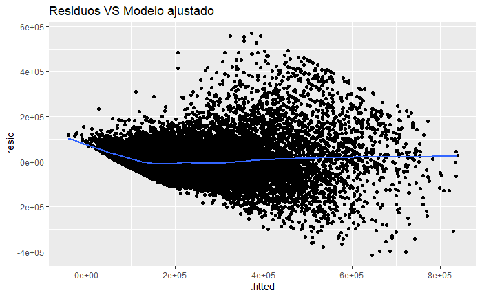

```r
## obtengo los residuos del modelo y los grafico con respecto al modelo ajustado
residuos <- augment(lmpatio,ar_propertiespatio)

ggplot(residuos, aes(.fitted, .resid)) +
  geom_point()+
  geom_hline(yintercept = 0) +
  geom_smooth(se = FALSE) +
  ggtitle("Residuos VS Modelo ajustado")
```

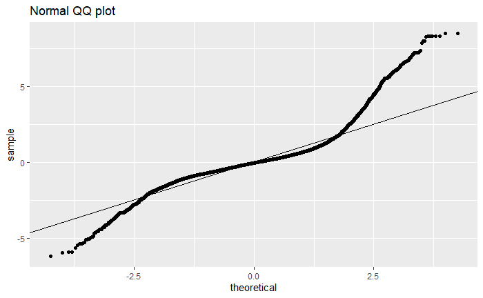

```r
#Grafico Q-Q de los residuos
ggplot(residuos, aes(sample= .std.resid))+
  stat_qq()+
  geom_abline()  + ggtitle('Normal QQ plot')
```

Del grafico de los residuos vs modelo ajustado no se evidencia una estructura clara, lo que indica que la varianza de todos los residuos en variable, comienza con poca varianza y van aumentando, esto nos lleva a decir que el criterio de homocedasticidad no se cumple.

En el grafico Normal QQ-plot, se observa que los errores no se distribuyen de forma normal debido a que en los extremos los mismos se diferencian de sus cuantiles teoricos.

### b) Calcular el modelo

Calcular el modelo log(price)=β0+β1log(rooms)+β2log(bathrooms)+β3log(surface_covered)+β4property_type+β5barrio+β6surface_patio

```r
#Calcular el modelo logaritmico
lmlog = lm(log(price) ~ log(rooms) + log(bathrooms) + log(surface_covered) + property_type + barrios + surface_patio, ar_propertiespatio)

summary(lmlog)
```

```
Call:
lm(formula = log(price) ~ log(rooms) + log(bathrooms) + log(surface_covered) +
    property_type + barrios + surface_patio, data = ar_propertiespatio)

Residuals:
    Min      1Q  Median      3Q     Max
-1.3123 -0.1452 -0.0030  0.1359  1.1231

Coefficients:
                            Estimate Std. Error t value Pr(>|t|)
(Intercept)                8.309e+00  1.868e-02 444.814  < 2e-16 ***
log(rooms)                -1.633e-02  3.760e-03  -4.343 1.41e-05 ***
log(bathrooms)             1.858e-01  3.786e-03  49.073  < 2e-16 ***
log(surface_covered)       7.796e-01  4.427e-03 176.109  < 2e-16 ***
property_typeDepartamento  2.157e-01  7.131e-03  30.246  < 2e-16 ***
property_typePH            6.257e-02  7.541e-03   8.297  < 2e-16 ***
barriosmedio               1.995e-01  4.792e-03  41.635  < 2e-16 ***
barriosalto                4.817e-01  4.891e-03  98.483  < 2e-16 ***
surface_patio              4.189e-03  7.866e-05  53.250  < 2e-16 ***
---
Signif. codes:  0 ‘***’ 0.001 ‘**’ 0.01 ‘*’ 0.05 ‘.’ 0.1 ‘ ’ 1

Residual standard error: 0.2245 on 45365 degrees of freedom
Multiple R-squared:  0.8208,    Adjusted R-squared:  0.8207
F-statistic: 2.597e+04 on 8 and 45365 DF,  p-value: < 2.2e-16
```

- Comparar la performance del modelo de 2.d con éste, tanto en términos de la variabilidad explicada cómo de su relación con los supuestos del modelo lineal. Re-interpretar los parámetros del modelo.

En cuanto a la variabilidad explicada de este nuevo modelo la cual se observa en el valor del R2 ajustado, nos da 82% lo que muestra que con este modelo podemos llegar a explicar mas que con los modelos implementados previamente.

De los coeficientes obtenidos en este modelo se puede ver que la variacion del precio estimado de una propiedad con todas la variables constantes, si el tipo de propiedad cambia de casa a PH esta tendria un aumento en un 6%, mientras que si se cambia esta misma por una propiedad tipo Departamento aumentaria en un 21%.

En cuanto a los coeficientes de las variables que se encuentran transformadas, el coeficiente para la variables log(surface_covered) es de 0.779 por lo que si se aumenta un 1% el valor de la superficie cubierta, el valor del precio esperado aumentaria en un 0.779%, como se observo en anteriores modelos aun con este en el cual las variables tienen una transformacion el coeficiente para la variable log(rooms) continua siendo negativo, lo que indica que si la variable de habitaciones aumenta un 1%, el valor del precio esperado disminuye en un 0.016%.

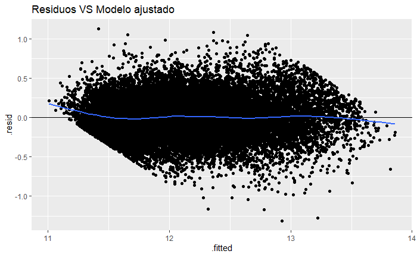

```r
## obtengo los residuos del modelo y los grafico con respecto al modelo ajustado
residuoslog <- augment(lmlog,ar_propertiespatio)

ggplot(residuoslog, aes(.fitted, .resid)) +
  geom_point()+
  geom_hline(yintercept = 0) +
  geom_smooth(se = FALSE) +
  ggtitle("Residuos VS Modelo ajustado")
```

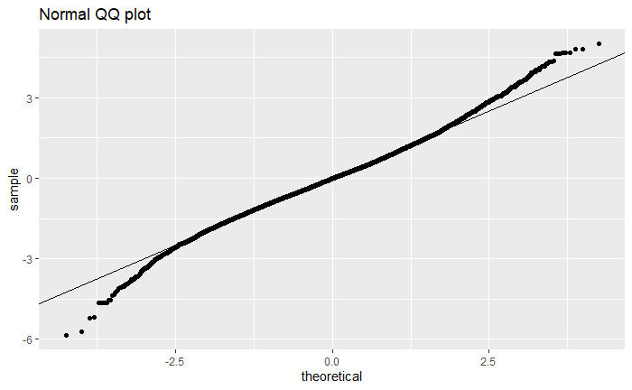

```r
#Grafico Q-Q de los residuos
ggplot(residuoslog, aes(sample= .std.resid))+
  stat_qq()+
  geom_abline()  + ggtitle('Normal QQ plot')
```

En cuanto a la distribucion de los residuos con respecto al modelo anterior estan mas concentrados en torno al cero lo que muestra que tienen menos dispersion, por lo que muestra que el modelo esta cerca a cumplir los supuestos del modelo lineal. En el grafico de QQ Plot las observaciones estan mas cerca de la recta, lo que quiere decir que la distribucion de los residuos estan mas cerca a una distribucion normal.

## 4. Dataframes anidados

### a) Anidar por la variable property_type

```r
#Agrupar por tipo de propiedad
ar_porpropiedad <- ar_propertiespatio %>%
  group_by(property_type) %>%
  nest()

ar_porpropiedad
```

| property_type | data |
| --- | --- |
| Casa |  |
| Departamento |  |
| PH |  |

### b) Construir para cada tipo de propiedad el modelo de 2.d e interpretar los resultados en cada caso. Qué diferencias encuentran entre los distintos modelos?

```r
# Crear una funcion para el modelo por cada tipo
regresion_lineal <- function(df){
  return (lm(price ~ . ,data = df))
}

#Ejecutar la funcion por cada tipo
modelosportipo = ar_porpropiedad %>%
  mutate(lmtipo = map(data, regresion_lineal))%>%
  mutate(tdy = map(lmtipo,tidy), gla = map(lmtipo, glance))

#Mostras las valores de evaluacion del parametro
modelosportipo%>%
  unnest(gla, .drop=TRUE)
```

| property_type | r.squared | adj.r.squared | sigma | statistic | p.value | df | logLik | AIC | BIC | deviance | df.residual |
| --- | --- | --- | --- | --- | --- | --- | --- | --- | --- | --- | --- |
| Casa | 0.5819662 | 0.5798242 | 87596.05 | 271.7015 | 9.69156e-218 | 7 | -15074.22 | 30164.44 | 30205.01 | 8.985163e+12 | 1171 |
| Departamento | 0.7850490 | 0.7850166 | 64491.42 | 24241.6301 | 0.00000e+00 | 7 | -497626.68 | 995269.35 | 995338.09 | 1.656379e+14 | 39825 |
| PH | 0.6844695 | 0.6840350 | 53853.32 | 1575.2485 | 0.00000e+00 | 7 | -53730.25 | 107476.49 | 107527.54 | 1.263609e+13 | 4357 |

Se observa que el mejor modelo de acuerdo al valor del R cuadrado ajustado seria el de tipo de propiedad Departamento, seguido de PH y por ultimo Casa, con respecto a los modelos realizados previamente, el unico que tendria un valor similar a estos seria el del tipo Departamento, por lo que podria decirse que es la variable que esta teniendo mas peso en los modelos generales.

```r
#mostrar los valores de los coeficientes de cada modelo
modelosportipo %>%
  unnest(tdy, .drop=TRUE) %>%
  filter(term != '(Intercept)')
```

| property_type | term | estimate | std.error | statistic | p.value |
| --- | --- | --- | --- | --- | --- |
| Casa | rooms | 5164.5763 | 2492.67690 | 2.071900 | 3.849331e-02 |
| Casa | bathrooms | 28765.3354 | 3694.53498 | 7.785915 | 1.515150e-14 |
| Casa | surface_covered | 1192.4048 | 64.44828 | 18.501732 | 3.024484e-67 |
| Casa | barriosmedio | 51696.1847 | 6276.86156 | 8.235992 | 4.715933e-16 |
| Casa | barriosalto | 154782.1363 | 7968.73166 | 19.423685 | 4.531807e-73 |
| Casa | surface_patio | 496.1877 | 97.56495 | 5.085716 | 4.261555e-07 |
| Departamento | rooms | -9174.2016 | 473.62237 | -19.370288 | 3.324353e-83 |
| Departamento | bathrooms | 31340.0865 | 691.67357 | 45.310516 | 0.000000e+00 |
| Departamento | surface_covered | 2739.2022 | 16.82556 | 162.800050 | 0.000000e+00 |
| Departamento | barriosmedio | 23086.5714 | 1676.58364 | 13.770009 | 4.847423e-43 |

[output cut: 8 more lines]